# Harry Potter kNN Padawan is Me

# 4 Training - Validation split

```r
# Set the seed

set.seed(666)
```

- Randomly sample the rows via their indexes (row number) We did 70-30 split

```r
# Data partitioning

train_index <- sample(1:nrow(hogwarts), 0.7 * nrow(hogwarts))
valid_index <- setdiff(1:nrow(hogwarts), train_index)
```

- Assign the randomly selected indexes to the dataset to create the training and validation sets

```r
# Create training and validation datasets

train_df <- hogwarts[train_index, ]
valid_df <- hogwarts[valid_index, ]
```

It’s a good idea to check the datasets before continuing

```r
nrow(train_df)
```

```
## [1] 513
```

```r
nrow(valid_df)
```

```
## [1] 221
```

```r
head(train_df)
```

```
##     Manipulative Resourceful Dismissive Intelligent Trusting Loyal
## 569            6           4          1           7        3     3
## 145            9           7          8           2        9     5
## 716            7           6          5           5        6     4
## 148            9           8          6           3        3     3
## 264            4           4          8          10        1     7
## 542            7           1          5           8        8     9
##     Stubborn Brave      House
## 569        7    10 Gryffindor
## 145        5     8  Slytherin
## 716        6     8 Gryffindor
## 148        7     2  Slytherin
## 264        7     7  Ravenclaw
## 542        5     7 Hufflepuff
```

```r
head(valid_df)
```

```
##   Manipulative Resourceful Dismissive Intelligent Trusting Loyal Stubborn
## 3            6           8          1           6        3     3        5
## 4            7           7          1           9        7     4        6
## 5           10           6          8           3        4     4        1
## 7            8           6          8           7        4     1        5
## 8            9           8          9           4        1     6        5
## 9            7           6          6           5        8     3        3
##   Brave     House
## 3     2 Slytherin
## 4     6 Slytherin
## 5     8 Slytherin
## 7     2 Slytherin
## 8     4 Slytherin
## 9     2 Slytherin
```

```r
str(train_df)
```

```
## 'data.frame':    513 obs. of  9 variables:
##  $ Manipulative: int  6 9 7 9 4 7 5 5 7 6 ...
##  $ Resourceful : int  4 7 6 8 4 1 8 5 7 10 ...
##  $ Dismissive  : int  1 8 5 6 8 5 7 7 7 4 ...
##  $ Intelligent : int  7 2 5 3 10 8 7 6 1 3 ...
##  $ Trusting    : int  3 9 6 3 1 8 2 8 9 7 ...
##  $ Loyal       : int  3 5 4 3 7 9 6 7 1 7 ...
##  $ Stubborn    : int  7 5 6 7 7 5 7 6 6 6 ...
##  $ Brave       : int  10 8 8 2 7 7 9 8 5 5 ...
##  $ House       : Factor w/ 4 levels "Gryffindor","Hufflepuff",..: 1 4 1 4 3 2 1 2 4 4 ...
```

```r
str(valid_df)
```

```
## 'data.frame':    221 obs. of  9 variables:
##  $ Manipulative: int  6 7 10 8 9 7 6 6 9 9 ...
##  $ Resourceful : int  8 7 6 6 8 6 6 6 6 8 ...
##  $ Dismissive  : int  1 1 8 8 9 6 6 6 8 3 ...
##  $ Intelligent : int  6 9 3 7 4 5 6 3 3 5 ...
##  $ Trusting    : int  3 7 4 4 1 8 8 6 3 6 ...
##  $ Loyal       : int  3 4 4 1 6 3 8 7 2 7 ...
##  $ Stubborn    : int  5 6 1 5 5 3 1 6 5 2 ...
##  $ Brave       : int  2 6 8 2 4 2 7 2 7 8 ...
##  $ House       : Factor w/ 4 levels "Gryffindor","Hufflepuff",..: 4 4 4 4 4 4 4 4 4 4 ...
```

# 5 Set new Padawan: Me

```r
padawan_1 <- data.frame(Manipulative = 2,
                        Resourceful = 8,
                        Dismissive = 2,
                        Intelligent = 7,
                        Trusting = 5,
                        Loyal = 10,
                        Stubborn = 7,
                        Brave = 9)

padawan_1
```

```
##   Manipulative Resourceful Dismissive Intelligent Trusting Loyal Stubborn
## 1            2           8          2           7        5    10        7
##   Brave
## 1     9
```

# 6 Normalization

+This is needed if predictors are on a different scale. +In this case, this is just for illustration.

```r
# Assign normalized data to a new dataframe
train_norm <- train_df
valid_norm <- valid_df
```

First, create a normalising algorithm using the 8 variables in the training set.

```r
# Just double checking we still have our 8 variables
names(train_df)
```

```
## [1] "Manipulative" "Resourceful"  "Dismissive"   "Intelligent"
## [5] "Trusting"     "Loyal"        "Stubborn"     "Brave"
## [9] "House"
```

```r
# Normalization algorithm

norm_values <- preProcess(train_df[, -c(9)],
                          method = c("center",
                                     "scale"))

# Normalizing training dataset using train_df

train_norm[, -c(9)] <- predict(norm_values,
                               train_df[, -c(9)])

head(train_norm)
```

```
##     Manipulative  Resourceful Dismissive Intelligent    Trusting
## 569   0.04996936 -0.861616004 -1.9804736   0.5703220 -1.24733813
## 145   1.33168346  0.420808590  1.0064565  -1.6767993  1.32247898
## 716   0.47720739 -0.006666275 -0.2736564  -0.3285265  0.03757043
## 148   1.33168346  0.848283455  0.1530479  -1.2273750 -1.24733813
## 264  -0.80450670 -0.861616004  1.0064565   1.9185948 -2.10394384
## 542   0.47720739 -2.144040598 -0.2736564   1.0197463  0.89417613
##          Loyal    Stubborn      Brave      House
## 569 -1.1562071  0.47268189  1.7542740 Gryffindor
## 145 -0.3249047 -0.38415843  0.9088606  Slytherin
## 716 -0.7405559  0.04426173  0.9088606 Gryffindor
## 148 -1.1562071  0.47268189 -1.6273796  Slytherin
## 264  0.5063976  0.47268189  0.4861539  Ravenclaw
## 542  1.3377000 -0.38415843  0.4861539 Hufflepuff
```

- Then using these normalizing algorithm, predict the normalized values of the validation set.

```r
# Normalizing validation dataset

valid_norm[, -c(9)] <- predict(norm_values,
                               valid_df[, -c(9)])


head(valid_norm)
```

```
##   Manipulative  Resourceful Dismissive Intelligent   Trusting       Loyal
## 3   0.04996936  0.848283455 -1.9804736   0.1208978 -1.2473381 -1.15620708
## 4   0.47720739  0.420808590 -1.9804736   1.4691706  0.4658733 -0.74055590
## 5   1.75892149 -0.006666275  1.0064565  -1.2273750 -0.8190353 -0.74055590
## 7   0.90444542 -0.006666275  1.0064565   0.5703220 -0.8190353 -1.98750943
## 8   1.33168346  0.848283455  1.4331608  -0.7779508 -2.1039438  0.09074646
## 9   0.47720739 -0.006666275  0.1530479  -0.3285265  0.8941761 -1.15620708
##      Stubborn      Brave     House
## 3 -0.38415843 -1.6273796 Slytherin
## 4  0.04426173  0.0634472 Slytherin
## 5 -2.09783908  0.9088606 Slytherin
## 7 -0.38415843 -1.6273796 Slytherin
## 8 -0.38415843 -0.7819662 Slytherin
## 9 -1.24099875 -1.6273796 Slytherin
```

- Finally, predict the normalized values for the new padawan (i.e. the new record)

```r
padawan_1_norm <- predict(norm_values, padawan_1)
padawan_1_norm
```

```
##   Manipulative Resourceful Dismissive Intelligent   Trusting    Loyal
## 1    -1.658983   0.8482835  -1.553769    0.570322 -0.3907324 1.753351
##    Stubborn    Brave
## 1 0.4726819 1.331567
```

# 7 Optimal k for kNN

First, create a df for accuracy using values from 1 to 19, 1 step at a time.

```r
accuracy_df <- data.frame(k = seq(1, 19, 1), accuracy = rep(1, 19))
accuracy_df
```

```
##     k accuracy
## 1   1        1
## 2   2        1
## 3   3        1
## 4   4        1
## 5   5        1
## 6   6        1
## 7   7        1
## 8   8        1
## 9   9        1
## 10 10        1
## 11 11        1
## 12 12        1
## 13 13        1
## 14 14        1
## 15 15        1
## 16 16        1
## 17 17        1
## 18 18        1
## 19 19        1
```

```r
# Still checking on train_norm

names(train_norm)
```

```
## [1] "Manipulative" "Resourceful"  "Dismissive"   "Intelligent"
## [5] "Trusting"     "Loyal"        "Stubborn"     "Brave"
## [9] "House"
```

```r
head(train_norm)
```

```
##     Manipulative  Resourceful Dismissive Intelligent    Trusting
## 569   0.04996936 -0.861616004 -1.9804736   0.5703220 -1.24733813
## 145   1.33168346  0.420808590  1.0064565  -1.6767993  1.32247898
## 716   0.47720739 -0.006666275 -0.2736564  -0.3285265  0.03757043
## 148   1.33168346  0.848283455  0.1530479  -1.2273750 -1.24733813
## 264  -0.80450670 -0.861616004  1.0064565   1.9185948 -2.10394384
## 542   0.47720739 -2.144040598 -0.2736564   1.0197463  0.89417613
##          Loyal    Stubborn      Brave      House
## 569 -1.1562071  0.47268189  1.7542740 Gryffindor
## 145 -0.3249047 -0.38415843  0.9088606  Slytherin
## 716 -0.7405559  0.04426173  0.9088606 Gryffindor
## 148 -1.1562071  0.47268189 -1.6273796  Slytherin
## 264  0.5063976  0.47268189  0.4861539  Ravenclaw
## 542  1.3377000 -0.38415843  0.4861539 Hufflepuff
```

```r
names(valid_norm)
```

```
## [1] "Manipulative" "Resourceful"  "Dismissive"   "Intelligent"
## [5] "Trusting"     "Loyal"        "Stubborn"     "Brave"
## [9] "House"
```

```r
head(valid_norm)
```

```
##   Manipulative  Resourceful Dismissive Intelligent   Trusting       Loyal
## 3   0.04996936  0.848283455 -1.9804736   0.1208978 -1.2473381 -1.15620708
## 4   0.47720739  0.420808590 -1.9804736   1.4691706  0.4658733 -0.74055590
## 5   1.75892149 -0.006666275  1.0064565  -1.2273750 -0.8190353 -0.74055590
## 7   0.90444542 -0.006666275  1.0064565   0.5703220 -0.8190353 -1.98750943
## 8   1.33168346  0.848283455  1.4331608  -0.7779508 -2.1039438  0.09074646
## 9   0.47720739 -0.006666275  0.1530479  -0.3285265  0.8941761 -1.15620708
##      Stubborn      Brave     House
## 3 -0.38415843 -1.6273796 Slytherin
## 4  0.04426173  0.0634472 Slytherin
## 5 -2.09783908  0.9088606 Slytherin
## 7 -0.38415843 -1.6273796 Slytherin
## 8 -0.38415843 -0.7819662 Slytherin
## 9 -1.24099875 -1.6273796 Slytherin
```

```r
# Using a loop function to find the best k

for (i in 1:19) {
  knn_pred <- class::knn(train_norm[, -c(9)],
                         valid_norm[, -c(9)],
                         cl = train_norm[, 9], k = i)
  accuracy_df[i, 2] <- confusionMatrix(knn_pred,
                                       factor(valid_norm[, 9]))$overall[1]
}

accuracy_df
```

```
##     k  accuracy
## 1   1 0.7782805
## 2   2 0.7873303
## 3   3 0.8325792
## 4   4 0.8416290
## 5   5 0.8416290
## 6   6 0.8687783
## 7   7 0.8506787
## 8   8 0.8461538
## 9   9 0.8642534
## 10 10 0.8506787
## 11 11 0.8552036
## 12 12 0.8597285
## 13 13 0.8823529
## 14 14 0.8733032
## 15 15 0.8914027
## 16 16 0.8959276
## 17 17 0.8959276
## 18 18 0.8733032
## 19 19 0.8914027
```

- If you like, plot the accuracies for different k for illustration.

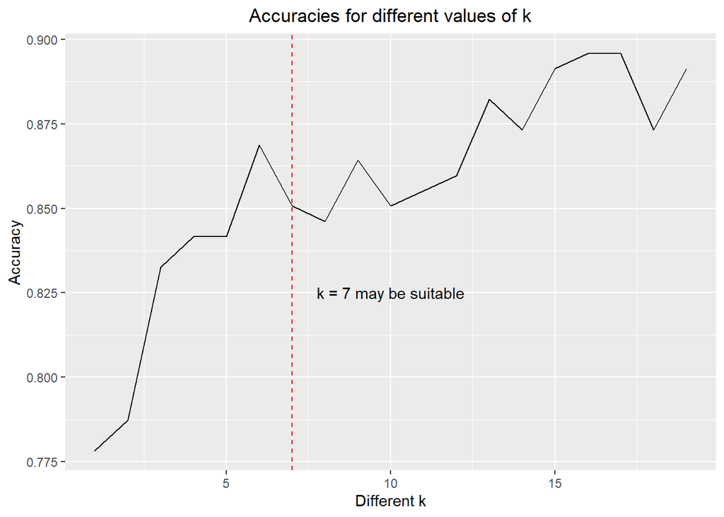

```r
# Plotting using ggplot2

ggplot(data = accuracy_df) + aes(x = k, y = accuracy) +
  geom_line() + xlab("Different k") + ylab("Accuracy") +
  ggtitle("Accuracies for different values of k") +
  theme(plot.title = element_text(hjust = 0.5)) +
  annotate("text", x = 10, y = 0.825, label = "k = 7 may be suitable") +
  geom_vline(xintercept = 7, linetype = "dashed", color = "red")
```

# 8 kNN for k = 7

```r
# Train the kNN model using k = 7

knn_pred_k7 <- class::knn(train = train_norm[, -c(9)],
                          test = valid_norm[, -c(9)],
                          cl = train_df$House,
                          k = 7)
```

```r
# Confusion Matrix for the model
confusionMatrix(knn_pred_k7, as.factor(valid_df[, 9]))
```

```
## Confusion Matrix and Statistics
##
##             Reference
## Prediction   Gryffindor Hufflepuff Ravenclaw Slytherin
##   Gryffindor         49          3         2         2
##   Hufflepuff          4         50         3         2
##   Ravenclaw           1          0        45         6
##   Slytherin           2          2         1        49
##
## Overall Statistics
##
##                Accuracy : 0.8733
##                  95% CI : (0.8221, 0.9141)
##     No Information Rate : 0.267
##     P-Value [Acc > NIR] : <2e-16
##
##                   Kappa : 0.831
##
##  Mcnemar's Test P-Value : 0.3165
##
## Statistics by Class:
##
##                      Class: Gryffindor Class: Hufflepuff Class: Ravenclaw
## Sensitivity                     0.8750            0.9091           0.8824
## Specificity                     0.9576            0.9458           0.9588
## Pos Pred Value                  0.8750            0.8475           0.8654
## Neg Pred Value                  0.9576            0.9691           0.9645
## Prevalence                      0.2534            0.2489           0.2308
## Detection Rate                  0.2217            0.2262           0.2036
## Detection Prevalence            0.2534            0.2670           0.2353
## Balanced Accuracy               0.9163            0.9274           0.9206
##                      Class: Slytherin
## Sensitivity                    0.8305
## Specificity                    0.9691
## Pos Pred Value                 0.9074
## Neg Pred Value                 0.9401
## Prevalence                     0.2670
## Detection Rate                 0.2217
## Detection Prevalence           0.2443
## Balanced Accuracy              0.8998
```

```r
# Associated probability of the prediction

knn_pred_k7_prob <- class::knn(train = train_norm[, -c(9)],
                               test = valid_norm[, -c(9)],
                               cl = train_norm$House,
                               k = 7,
                               prob = TRUE)

knn_pred_k7_prob
```

```
##   [1] Slytherin  Slytherin  Ravenclaw  Ravenclaw  Slytherin  Ravenclaw
##   [7] Hufflepuff Slytherin  Slytherin  Slytherin  Slytherin  Slytherin
##  [13] Slytherin  Slytherin  Slytherin  Slytherin  Ravenclaw  Slytherin
##  [19] Slytherin  Slytherin  Slytherin  Slytherin  Slytherin  Slytherin
##  [25] Slytherin  Slytherin  Slytherin  Slytherin  Slytherin  Gryffindor
##  [31] Slytherin  Hufflepuff Slytherin  Slytherin  Slytherin  Slytherin
##  [37] Ravenclaw  Slytherin  Slytherin  Slytherin  Slytherin  Slytherin
##  [43] Slytherin  Slytherin  Slytherin  Ravenclaw  Slytherin  Slytherin
##  [49] Slytherin  Slytherin  Slytherin  Slytherin  Slytherin  Slytherin
##  [55] Slytherin  Slytherin  Gryffindor Slytherin  Slytherin  Ravenclaw
##  [61] Ravenclaw  Ravenclaw  Ravenclaw  Ravenclaw  Gryffindor Ravenclaw
##  [67] Ravenclaw  Ravenclaw  Ravenclaw  Ravenclaw  Ravenclaw  Ravenclaw
##  [73] Ravenclaw  Ravenclaw  Ravenclaw  Ravenclaw  Ravenclaw  Ravenclaw
##  [79] Ravenclaw  Ravenclaw  Slytherin  Ravenclaw  Ravenclaw  Ravenclaw
##  [85] Ravenclaw  Ravenclaw  Ravenclaw  Ravenclaw  Ravenclaw  Ravenclaw
```

[output cut: 56 more lines]

- Using the trained model, predict the class (i.e. House) of the validation set.

```r
# Predicting outcome using the validation data

knn_pred_k7_valid <- class::knn(train = train_norm[, -c(9)],
                                test = valid_norm[, -c(9)],
                                cl = train_norm[, c(9)],
                                k = 7)


knn_pred_k7_valid
```

```
##   [1] Slytherin  Slytherin  Ravenclaw  Ravenclaw  Slytherin  Ravenclaw
##   [7] Hufflepuff Slytherin  Slytherin  Slytherin  Slytherin  Slytherin
##  [13] Slytherin  Slytherin  Slytherin  Slytherin  Ravenclaw  Slytherin
##  [19] Slytherin  Slytherin  Slytherin  Slytherin  Slytherin  Slytherin
##  [25] Slytherin  Slytherin  Slytherin  Slytherin  Slytherin  Gryffindor
##  [31] Slytherin  Slytherin  Slytherin  Slytherin  Slytherin  Slytherin
##  [37] Ravenclaw  Slytherin  Slytherin  Slytherin  Slytherin  Slytherin
##  [43] Slytherin  Slytherin  Slytherin  Ravenclaw  Slytherin  Slytherin
##  [49] Slytherin  Slytherin  Slytherin  Slytherin  Slytherin  Slytherin
##  [55] Slytherin  Slytherin  Gryffindor Slytherin  Slytherin  Ravenclaw
##  [61] Ravenclaw  Ravenclaw  Ravenclaw  Ravenclaw  Gryffindor Ravenclaw
##  [67] Ravenclaw  Ravenclaw  Ravenclaw  Ravenclaw  Ravenclaw  Ravenclaw
##  [73] Ravenclaw  Ravenclaw  Ravenclaw  Ravenclaw  Ravenclaw  Ravenclaw
##  [79] Ravenclaw  Ravenclaw  Slytherin  Ravenclaw  Ravenclaw  Ravenclaw
##  [85] Ravenclaw  Ravenclaw  Ravenclaw  Ravenclaw  Ravenclaw  Ravenclaw
```

[output cut: 23 more lines]

```r
# Compute the probability.

attr(knn_pred_k7_prob, "prob")
```

```
##   [1] 1.0000000 0.5714286 0.5714286 0.5714286 0.7142857 0.5714286 0.7142857
##   [8] 0.5714286 0.7142857 1.0000000 0.8571429 0.8571429 1.0000000 0.7142857
##  [15] 0.5714286 0.8571429 0.5714286 0.7142857 0.8571429 0.5714286 1.0000000
##  [22] 0.8571429 0.7142857 0.7142857 1.0000000 0.8571429 1.0000000 0.8571429
##  [29] 0.7142857 0.8571429 0.8571429 0.4285714 1.0000000 0.5714286 0.8571429
##  [36] 0.5714286 0.5714286 0.8571429 0.8571429 0.8571429 1.0000000 0.8571429
##  [43] 0.4285714 0.7142857 1.0000000 0.8571429 0.8571429 1.0000000 0.5714286
##  [50] 0.7142857 0.8571429 1.0000000 0.7142857 0.5714286 0.7142857 1.0000000
##  [57] 0.5714286 0.4285714 1.0000000 0.4285714 1.0000000 0.8571429 0.8571429
##  [64] 0.7142857 0.7142857 1.0000000 0.8571429 0.7142857 0.7142857 0.8571429
##  [71] 0.5714286 0.8571429 0.7142857 0.8571429 1.0000000 0.5714286 1.0000000
##  [78] 0.8571429 0.8571429 0.5714286 0.5714286 0.5714286 0.7142857 0.8571429
##  [85] 0.8571429 1.0000000 0.8571429 0.7142857 0.5714286 0.5714286 1.0000000
##  [92] 0.4285714 1.0000000 0.4285714 0.7142857 0.8571429 0.8571429 0.8571429
##  [99] 0.8571429 0.8571429 0.7142857 0.5714286 0.8571429 0.7142857 0.8571429
```

[output cut: 17 more lines]

# 9 Sorting hat for the new padawan

- Now predict the class (i.e. House) for the new padawan using the same approach.
- Compute the probabilities, so we know how probable was each class for this new padawan.

```r
# checking names

names(train_norm)
```

```
## [1] "Manipulative" "Resourceful"  "Dismissive"   "Intelligent"
## [5] "Trusting"     "Loyal"        "Stubborn"     "Brave"
## [9] "House"
```

```r
names(padawan_1_norm)
```

```
## [1] "Manipulative" "Resourceful"  "Dismissive"   "Intelligent"
## [5] "Trusting"     "Loyal"        "Stubborn"     "Brave"
```

```r
# Predicting the outcome of the new padawan

padawan_1_pred <- class::knn(train = train_norm[, -c(9)],
                             test = padawan_1_norm,
                             cl = train_norm$House,
                             k =7)

padawan_1_pred
```

```
## [1] Gryffindor
## Levels: Gryffindor Hufflepuff Ravenclaw Slytherin
```

- Now let’s do the prob

```r
# probability of the padawan outcome
padawan_1_pred_prob <- class::knn(train = train_norm[, -c(9)],
                                  test = padawan_1_norm[, -c(9)],
                                  cl = train_norm$House,
                                  k = 7,
                                  prob = TRUE)

padawan_1_pred_prob
```

```
## [1] Gryffindor
## attr(,"prob")
## [1] 0.7142857
## Levels: Gryffindor Hufflepuff Ravenclaw Slytherin
```